# PCA analysis of pool-seq allele frequencies

# Introduction

F-stats analysis does not show any sign of population structure or isolation by ditance. Another way to look at this is to do a PCA of allele frequencies and see if there is any sign of samples clustering by gorgraphical distance.

To estimate allele frequencies, `snape-pooled` was run on each sample individually. To start out, this was restricted to the 716,989 “thinned” SNPs used for FStats.

# Required Libraries

```r
library(dplyr)
library(stringr)
library(PCAtools)
```

# Read in data

The output of `snape-pooled` is a little funky. It will skip a few SNPs, I am guessing this is where there are no data in the pilup. It will also produce a few truncated lines with an asterisk in the “number of reference nucleotides” column, and nothing else.

To work around these behaviours, we need to get the complete list of possible sites, independent of the sites presented in each `snape-pooled` output file. Then each `snape-pooled` input file, left join to the data to add the allele frequencies, allowing for some NAs to enter the read data.

Files and directories

```r
data.dir <-"../variantCalling/SNAPE/samples/"
sites.file <- "../variantCalling/SNAPE/samples/thinned.sites"
snape.files <- paste(data.dir, list.files(path = data.dir, pattern = "*.out"), sep = "")
```

Get all the sites

```r
sites <- read.table(sites.file,
                    col.names = c("contig",
                                 "site"))
sites$key <- paste(sites$contig,
                   sites$site,
                   sep = "_")
```

A `data.frame` for the frequencies

```r
freqs <- sites
```

Loop through each `snape-pooled` file. Make the key, rename col 11 (the allele frequency) to the sample name and left join to the frequencies table.

```r
for(idx in 1:length(snape.files)){
  tmp <- read.table(snape.files[idx], fill = T)
  names(tmp)[11] <- str_split(str_extract(snape.files[idx],
                                          "[A-Z].bam.out"),
                              "\\.",
                              simplify = T)[,1]
  tmp$key <- paste(tmp[,1], tmp[,2], sep = "_")
  freqs <- left_join(freqs, tmp[,c(12, 11)], by = "key")
}
```

# PCA

Run a basic PCA on the frequencies. Not that `prcomp` will not accepts missing values. We can catch these by applying `sum` to get rows that contain 1 or more NAs.

```r
# How many rows contain at leas 1 NA
sum(is.na(apply(freqs[,4:11], 1, sum)))
```

```
## [1] 40
```

```r
freqs.clean <- as.matrix(freqs[which(!(is.na(apply(freqs[,4:11], 1, sum)))), 4:11])
row.names(freqs.clean) <- freqs[which(!(is.na(apply(freqs[,4:11], 1, sum)))), 3]
```

How many SNPS do we have in the data after cleaning for NAs?

```r
length(row.names(freqs.clean))
```

```
## [1] 716949
```

```r
#p <- pca(freqs.clean, scale = T, center = T)
p <- pca(freqs.clean)
summary(p)
```

```
##            Length Class      Mode
## rotated         8 data.frame list
## loadings        8 data.frame list
## variance        8 -none-     numeric
## sdev            8 -none-     numeric
## metadata        0 -none-     NULL
## xvars      716949 -none-     character
## yvars           8 -none-     character
## components      8 -none-     character
```

A “biplot” of the samples on PCs 1 and 2

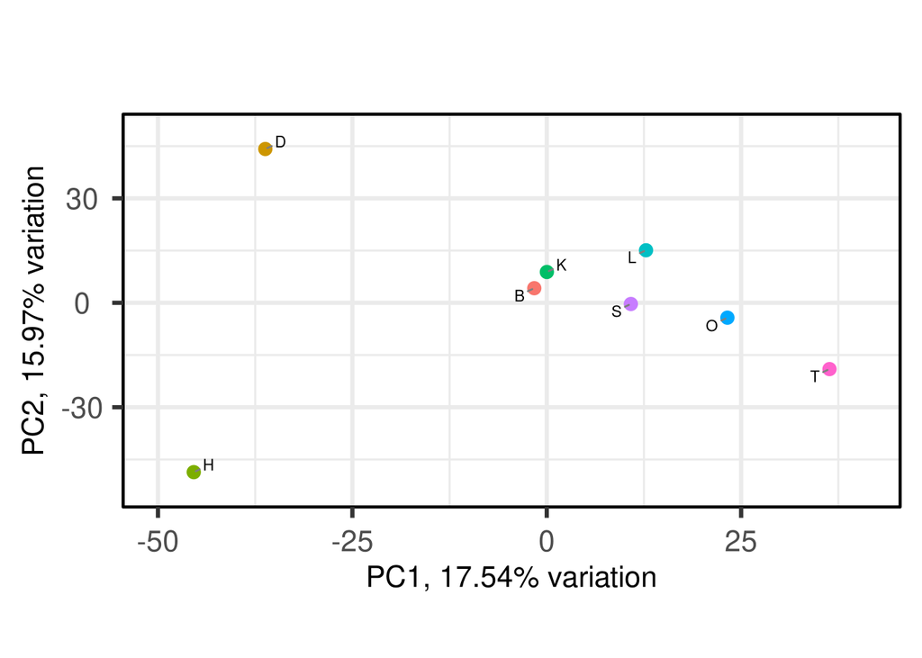

```r
biplot(p, lab = p$yvars)
```

Superficially, it looks like this might reflect the north - south transect, but the samples are not in the right order.

We can see this if we plot PC1 versus latitude.

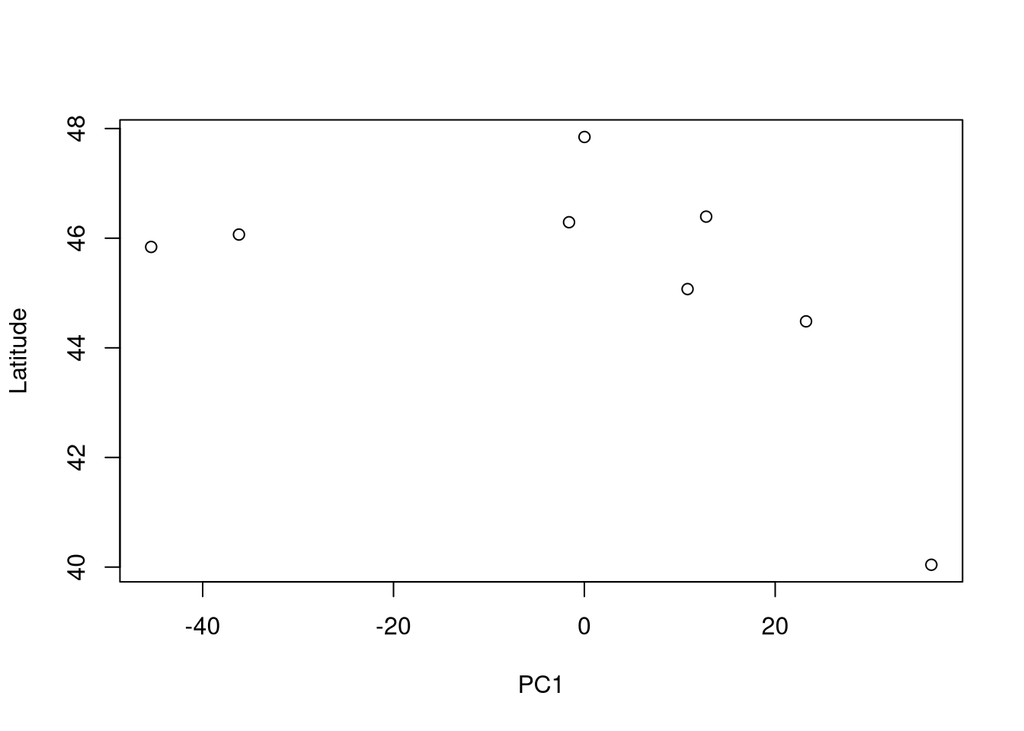

```r
site.info <- read.table("../poolFstat/siteLocations.txt", header = T)
plot(p$rotated$PC1, site.info$Lat, xlab = "PC1", ylab = "Latitude")
```

# Conclusion

PCA does not reveal any weak isolation by distance that is not picked up by the fstats analysis.